# Inteligencia Artificial Generativa (AI Gen)

Redes generativas antagónicas (GANs)

Autor: Paulo Veiga, Claudio Righetti, Marco Sorondo (Universidad Austral)  
Última modificación: 2026-10-21

01IA generativa de visión 02Introducción a las GANs 03Slanted Land 04Tipos y aplicaciones 05Limitaciones y cierre

01

IA generativa de visión

IA generativa de visión

## IA Generativa de Visión

**IA generativa de visión:** modelos que aprenden la distribución de un conjunto de imágenes, o sea su estructura interna, y con ella crean imágenes nuevas: no estaban en los datos, pero podrían haber estado.

IA generativa de visión

## ¿Qué es la IA Generativa de Visión?

**La IA visual se diseñó primero para analizar imágenes que ya existen: clasificarlas, detectar objetos o medir estructuras. Eso es la IA discriminativa, que aprende a distinguir entre categorías. La IA generativa aprende a crear contenido visual que no existía antes.**

AspectoIA DiscriminativaIA Generativa

¿Qué hace?Analiza y clasifica lo que ya existeCrea contenido nuevo que no existía

Pregunta típica"¿Este dígito es un 7?""Genera un 7"

Lo que aprendeA distinguir entre categoríasLa estructura interna de los datos

SalidaUna etiqueta o un númeroUna imagen, un sonido, un texto

EjemploClasificador de dígitos de MNISTcGAN que genera el dígito pedido

IA generativa de visión

## Línea de tiempo: el camino hasta hoy

Un campo en aceleración constante. Este curso arranca con el hito más influyente de la era de las GANs.

1

#### Era Estadística · 1950s–2000s

Redes neuronales, backpropagation. Resultados prometedores en teoría, pero muy limitados visualmente en la práctica.

2

#### Redes convolucionales (CNN) · 2012–hoy

Redes que aprenden filtros para analizar imágenes y dominan la visión supervisada. También entran en la IA generativa: con CNN más rápidas y profundas, la super-resolución aumenta la resolución de una imagen, y DCGAN (2015) las usa para generar.

3

#### Era de las GANs · 2014–2020

Ian Goodfellow publica la GAN original. Primera generación fotorrealista de imágenes. El campo explota en variantes y aplicaciones.

4

#### Era de la Difusión · 2020–hoy

DALL·E, Stable Diffusion, Midjourney. Control por texto, generación de vídeo, modelos de base masivos.

5

#### SAM & Modelos de Segmentación · 2023–hoy

Meta lanza Segment Anything Model (SAM). Segmentación interactiva de cualquier objeto en cualquier imagen. Prompteable con puntos, cajas o máscaras — sin reentrenamiento.

Este curso empieza con el hito más influyente de la era de las GANs: las Generative Adversarial Networks.

IA generativa de visión

## Los modelos que veremos en el curso

Tres familias de redes — tres bloques temáticos dedicados. Cada modelo responde una pregunta diferente: al final del curso, sabremos cuándo usar cada uno.

### GANs — Generative Adversarial Networks

Dos redes que compiten: una genera, la otra evalúa.

Casos

- Deepfakes
- StyleGAN
- Generación de datos sintéticos (imágenes médicas, entre otras)

Pregunta: ¿Cómo generar imágenes realistas que "engañen" a un evaluador?

### Diffusion Networks

Aprenden a reconstruir una imagen desde el ruido, paso a paso.

Casos

- Stable Diffusion
- DALL·E
- Midjourney

Pregunta: ¿Cómo generar imágenes diversas y controlables a partir de una descripción?

### CNN — Redes neuronales convolucionales

Aprenden filtros que detectan bordes, texturas y formas, y los combinan capa a capa. Nacieron para analizar imágenes, y en la IA generativa son la pieza de base.

Casos

- Clasificar imágenes, y detectar y segmentar objetos
- Super-resolución: aumentar la resolución de una imagen (SRGAN le suma una GAN para el detalle fino)
- El Generador y el Discriminador de DCGAN: el Generador sube de resolución con convoluciones transpuestas

Pregunta: ¿Cómo ve una red una imagen, para reconocer qué hay o para mejorarla?

IA generativa de visión

## Tabla comparativa rápida

Esta tabla no es para memorizar — es para consultar cuando tengas un problema real y necesites decidir qué herramienta usar.

CriterioGANsDiffusion NetworksCNN

¿Para qué sirve?Generar imágenes realistas, transformar modalidades, aumentar datosGenerar imágenes desde texto o guías visuales con alta diversidadReconocer qué hay en una imagen (clasificar, detectar, segmentar) y transformarla, por ejemplo aumentar su resolución

VelocidadMuy rápida (una pasada)Lenta (muchos pasos iterativos)Muy rápida

ControlModeradoAlto (guiado por texto)Bajo: la misma entrada da siempre la misma salida

FortalezaVelocidad + realismoDiversidad + controlabilidadDetectar patrones locales con pocos parámetros (filtros compartidos)

LimitaciónInestabilidad, mode collapseLento, costoso computacionalmenteSola no inventa detalle: al aumentar la resolución minimizando el error cuadrático, la imagen sale sin detalle fino (por eso SRGAN le suma una GAN)

Caso de uso típicoSuper-resolución (SRGAN), traducción de imágenes (Pix2Pix, CycleGAN)Imágenes desde texto (Stable Diffusion, DALL·E, Midjourney)Clasificación de imágenes, detección de objetos, super-resolución; Generador y Discriminador de DCGAN

01IA generativa de visión 02Introducción a las GANs 03Slanted Land 04Tipos y aplicaciones 05Limitaciones y cierre

02

Introducción a las GANs

Introducción a las GANs

Generative Adversarial Networks (GANs)

Introducción a las GANs

## Punto de partida

**"¿Cómo enseñarle a una máquina a crear algo que nunca ha visto?"**

### La idea central

En lugar de enseñarle a una red a crear directamente, haz que compita contra otra red que aprende a detectar sus errores. La presión de la competencia hace que ambas mejoren continuamente.

### El recorrido de este capítulo

- De dónde vienen las GANs y cómo evolucionaron
- Cómo funcionan por dentro — sin fórmulas, con intuición
- Para qué sirven y dónde tienen límites
- Dónde se aplican: productos visuales, datos sintéticos e imágenes médicas

Introducción a las GANs

## El origen: una noche en un bar (2014)

- Montreal, junio de 2014. Ian Goodfellow, 27 años, propone en una conversación de bar una idea aparentemente simple: ¿y si en lugar de una sola red, usamos dos? Una que genera, otra que evalúa. Que compitan.
- Sus colegas son escépticos. Esa misma noche implementa el prototipo. Funciona en el primer intento.

"La idea más interesante en machine learning en los últimos 20 años." — Yann LeCun

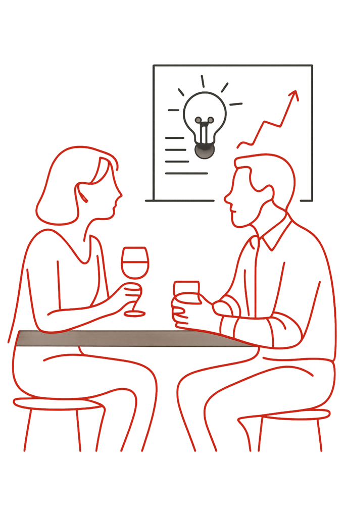

Introducción a las GANs

## Modelo Mental Para Entenderlo

**Un experimento mental: el mundo de los rostros. Imaginad una sociedad donde existen miles de rostros reales con características reconocibles. En esa sociedad aparecen dos personajes con objetivos opuestos:**

El FalsificadorEl Detective

Objetivo: crear rostros que parezcan pertenecer a ese mundo.Objetivo: distinguir los rostros reales de los falsos.

Método: prueba y error. Genera un rostro, recibe feedback, ajusta, repite. Puede estudiar todos los rostros reales que quiera, pero no sabe cómo se fabrican.Ventaja: ve ambos tipos — los reales del dataset y los que produce el falsificador. Como el falsificador mejora constantemente, él también tiene que mejorar.

**¿Qué pasa cuando estos dos compiten durante miles — o millones — de rondas? Los dos se vuelven extraordinariamente buenos en lo suyo.**

Introducción a las GANs

## Arquitectura de una GAN

Lo que acabamos de describir con el falsificador y el detective tiene una arquitectura técnica precisa. Cada elemento de la analogía corresponde a un componente real de la red:

AnalogíaComponente técnicoFunción

El FalsificadorGenerador (G)Transforma ruido aleatorio en imágenes sintéticas

Los rostros falsosImágenes generadasOutput del Generador — al principio, puro ruido visual

El DetectiveDiscriminador (D)Clasifica cada imagen como "real" o "falsa" con un score entre 0 y 1

El veredictoSeñal de pérdida (loss)Número que mide el error de cada red y guía su aprendizaje

Las rondas de competenciaÉpocas de entrenamientoCiclos en los que ambas redes actualizan sus parámetros internos

Introducción a las GANs

## Arquitectura de una "Vanilla" GAN

[figure not shown]

**[¿Qué es una GAN? - Explicación sobre las redes generativas antagónicas - AWS](https://aws.amazon.com/es/what-is/gan/)**

Introducción a las GANs

## Entrenamiento paso a paso

1

#### El Generador produce su primer intento

Recibe como entrada un vector de ruido aleatorio — números al azar que representan un punto en un espacio de posibilidades. Con ese ruido como semilla, produce una imagen. Al principio del entrenamiento, esa imagen es literalmente ruido visual — manchas sin forma ni sentido. Analogía: el falsificador en su primer día. No sabe nada de los rostros reales — produce garabatos.

2

#### El Discriminador evalúa

Recibe dos tipos de inputs en cada ronda: imágenes reales del dataset de entrenamiento e imágenes falsas producidas por el Generador en el Paso 1. Su tarea: asignar a cada imagen una probabilidad de ser real (entre 0 y 1). Al principio tiene la tarea fácil — las imágenes del Generador son obviamente falsas.

3

#### El Discriminador emite su veredicto

Produce un número entre 0 y 1: cerca de 1 → "Esto es real"; cerca de 0 → "Esto es claramente falso"; cerca de 0.5 → "No tengo idea". Cuando el Generador logra que el Discriminador dé 0.5 de forma consistente, es el éxito.

4

#### Ambos aprenden del resultado

El veredicto se convierte en señal de aprendizaje: el Generador ajusta sus parámetros para engañar mejor la próxima vez; el Discriminador ajusta los suyos para detectar mejor. Ambos actualizan simultáneamente — cada uno aprende del error del otro.

5

#### El ciclo se repite miles de veces

Generar → evaluar → aprender. Este loop puede repetirse cientos de miles de veces. Con cada iteración, el Generador produce imágenes más convincentes y el Discriminador se vuelve más exigente. Al final, el ojo humano no puede distinguir lo real de lo generado.

01IA generativa de visión 02Introducción a las GANs 03Slanted Land 04Tipos y aplicaciones 05Limitaciones y cierre

03

Slanted Land

Slanted Land

## El Problema: ¡Bienvenidos a Slanted Land! 🌀

Imagina un mundo peculiar llamado Slanted Land, donde absolutamente todo se inclina: los árboles, las casas, las personas e incluso la pizza que comen los gatos. En este universo, la norma es la inclinación.

### Universo Inclinado

Todo, desde la gravedad hasta las cejas de sus habitantes, está en un ángulo distintivo.

### Rostros "Normales"

Solo existen los rostros inclinados; un rostro recto les resulta completamente alienígena.

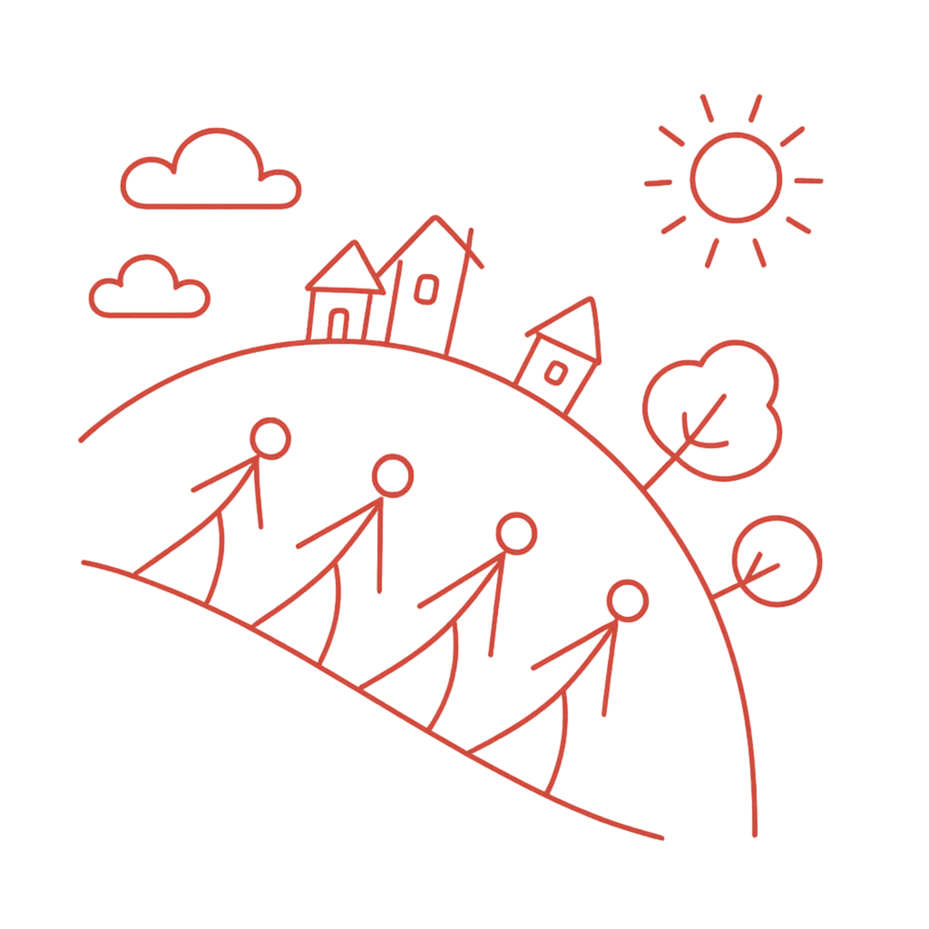

Slanted Land

## El problema urgente

La app de citas de Slanted Land, TiltedTinder, necesita generar fotos de perfil para sus usuarios. Pero solo tienen 4 fotos reales en toda su base de datos. Con tan pocos datos, nadie encuentra pareja. ¡La supervivencia romántica de toda una civilización inclinada depende de nuestra GAN! 💘

[Basado en «A Friendly Introduction to Generative Adversarial Networks», de Luis Serrano (ver video)](https://www.youtube.com/watch?v=8L11aMN5KY8&t=16s)

Slanted Land

## El mundo de Slanted Land

### Imágenes 2×2 píxeles

Cada imagen se representa como una pantalla con 4 celdas — cada celda tiene un valor entre 0 (blanco) y 1 (negro).

### Dataset real

Son imágenes de personas inclinadas. El Generador va a aprender a producir imágenes que se parezcan a esas personas.

### Red de una sola capa

La arquitectura más simple posible — ideal para entender los fundamentos sin complejidad adicional.

[figure not shown]

Slanted Land

## Los datos reales: caras con patrón

Las "caras" de Slanted Land, codificadas como píxeles, tienen un patrón consistente:

- Esquinas oscuras en la diagonal principal (arriba-izquierda y abajo-derecha): valor alto
- Esquinas claras en la diagonal secundaria (arriba-derecha y abajo-izquierda): valor bajo

Ese patrón diagonal es la "firma" de una cara real. El Discriminador tiene que aprenderlo para poder distinguirla del ruido.

[figure not shown]

Slanted Land

## Caras vs. ruido: los dos tipos de imágenes

Caras (imágenes reales)Ruido (imágenes falsas)

Valores altos en la diagonal principal, bajos en la secundaria. Patrón estructurado y reconocible.Valores sin patrón, distribuidos aleatoriamente. Sin estructura diagonal. El Discriminador debe aprender a distinguirlos a partir de esos valores numéricos.

[figure not shown]

Slanted Land

## Construyendo el Discriminador

**¿qué píxeles importan?**

- Los píxeles de la diagonal principal son grandes → reciben peso positivo (+1)
- Los píxeles de la diagonal secundaria son pequeños → reciben peso negativo (−1)

Asigna estos pesos a cada posición: +1 para las que caracterizan una cara, −1 para las que no la caracterizan.

[figure not shown]

Slanted Land

## Construyendo el Discriminador

**Calculo del Score**

El score de una imagen = suma ponderada de sus valores de píxel × pesos aprendidos:

Cara prototipoImagen de ruido

1×(+1) + 0×(−1) + 0×(−1) + 1×(+1) = 20.25×(+1) + 1×(−1) + 0.5×(−1) + 0.75×(+1) = −0.5

Score > 1 → Real ✓Score < 1 → Falsa ✓

[figure not shown]

Slanted Land

## Discriminador Como red neuronal

La entrada no calcula: x₁…x₄ son los píxeles. El cálculo lo hace la primera capa, que acá es una sola neurona. Para la cara prototipo: σ(1×(+1) + 0×(−1) + 0×(−1) + 1×(+1) − 1) = σ(1)

### Entradas (x)

x₁=1, x₂=0, x₃=0, x₄=1

### Pesos (w)

w₁=+1, w₂=−1, w₃=−1, w₄=+1

### Sesgo (b)

b = −1, parte de la neurona de salida

### Suma ponderada

1(+1)+0(−1)+0(−1)+1(+1) + b = 2 − 1 = 1

### Sigmoid

σ(1) ≈ 0.73 → imagen real

[figure not shown]

Slanted Land

## Función Sigmoid: la activación del Discriminador

**La función sigmoid convierte cualquier número real en una probabilidad entre 0 y 1. Es la función de activación que usa el Discriminador para emitir su veredicto.**

### Rango acotado

Devuelve valores entre 0 y 1; se lee como probabilidad.

### Diferenciable

Es suave en todo punto; permite backpropagation.

### Monótona creciente

Si sube la entrada, sube la salida; conserva el orden.

### Punto medio en 0

σ(0) = 0.5; umbral natural de decisión.

σ(x) = 1 / (1 + e⁻ˣ)

Slanted Land

## Pongamos todo junto del Discriminador

Cuando la cara prototipo pasa por la red completaCuando la imagen de ruido pasa por la misma red

**σ(1) = 0.73 → "Estoy un 73% seguro de que esto es real"****σ(−1.5) = 0.18 → "Estoy solo un 18% seguro de que esto sea real"**

**Como 0.73 > 0.5, clasifica correctamente la imagen como real ✓****Como 0.18 < 0.5, clasifica correctamente la imagen como falsa ✓**

[figure not shown]

Slanted Land

## El Generador: el objetivo opuesto

Las dos redes leen el mismo número, D(·), pero quieren resultados contrarios.

FactorDiscriminador (D)Generador (G)

EntradaUna imagen x de 4 píxelesUn número aleatorio z, entre 0 y 1

SalidaUn número, D(x)Una imagen G(z) de 2×2

QuiereD(x) → 1 si la imagen es real; D(G(z)) → 0 si es falsaD(G(z)) → 1

Slanted Land

## Construyendo el Generador

**El Generador en acción: z = 0.7 → imagen**

- Con z = 0.7 como entrada y los pesos aprendidos, el Generador produce una imagen que reproduce el patrón diagonal de las caras reales. El Generador aprendió a engañar al Discriminador.
- El resultado muestra el patrón diagonal característico de las caras de Slanted Land: valores altos en la diagonal principal, bajos en la secundaria. El Generador internalizó la estructura del dataset real.

[figure not shown]

Slanted Land

## Proceso de Entrenamiento

Hasta acá pusimos los pesos a mano (+1 y −1, y los sesgos). En la práctica, cada red los aprende sola, repitiendo tres pasos:

1

#### Predecir

El Discriminador mira una imagen y da un score entre 0 y 1.

2

#### Medir el error

Compara el score con el objetivo: 1 si la imagen es real, 0 si es falsa. La función que mide cuánto se equivocó se llama binary cross-entropy.

3

#### Ajustar los pesos

Backpropagation mueve cada peso en la dirección que baja el error. El Generador hace lo mismo con el objetivo contrario: que el Discriminador se equivoque.

Slanted Land

## Binary cross-entropy: los dos casos del Discriminador

**La propiedad clave: el error es grande cuando la predicción está lejos del objetivo, y pequeño cuando está cerca. Esto guía el aprendizaje en la dirección correcta.**

[figure not shown]

Slanted Land

## Loss Function: Discriminador — imagen real

- Predicción = 1 (imagen real).
- Error = −ln(predicción).
- Predicción baja → alto error. Predicción alta → bajo error.
- El Discriminador quiere acercarse a 1 cuando ve imágenes reales.

[figure not shown]

Slanted Land

## Loss Function: Generador — imagen falsa

- Predicción = 0 (imagen falsa).
- Error = −ln(1−predicción).
- Predicción alta → alto error.
- El Generador quiere que el Discriminador le asigne score alto (cercano a 1) — lo opuesto al objetivo del Discriminador.

[figure not shown]

Slanted Land

## Backpropagation: el procedimiento paso a paso

1

#### Calcular el error

**La binary cross-entropy da un número que mide qué tan lejos estuvo la red de la respuesta correcta.**

2

#### Derivar la sensibilidad de cada peso

**Con la regla de la cadena se calcula ∂E/∂w para cada peso: si subo este peso un poco, ¿el error sube o baja?**

3

#### Actualizar en la dirección opuesta al gradiente

**w_nuevo = w_actual − α · (∂E/∂w) — α (learning rate) controla el tamaño del paso.**

4

#### Repetir para todos los pesos, en ambas redes

**El cálculo se ejecuta para cada peso del Discriminador y del Generador de forma simultánea.**

Slanted Land

## Backpropagation: ejemplo con Slanted Land

**Con el error del Discriminador = 1.14 y output D(G(z)) = 0.68, calculamos el ajuste concreto usando la derivada ∂E/∂wᵢ = −[1 − D(x)] · xᵢ:**

PíxelValor xᵢ∂E/∂wα = 0.1w_nuevo

Arriba-izq (diagonal)0.25−0.32 × 0.25 = −0.08−0.1 × (−0.08)1 + 0.008 = 1.008 ↑

Arriba-der1.00−0.32 × 1.00 = −0.32−0.1 × (−0.32)−1 + 0.032 = −0.968 ↑

Slanted Land

## El ciclo completo: Generador y Discriminador juntos

En cada vuelta entra un lote: m imágenes reales y m generadas. El Discriminador da un veredicto por imagen, y con esos veredictos se hacen dos pasos de backpropagation, uno por red: el del Discriminador usa los errores de las reales y de las generadas; el del Generador, solo los de las generadas.

[figure not shown]

Slanted Land

## El error del Discriminador

El Discriminador recibió una imagen falsa pero le asignó un score de 0.68 (quería dar 0):

- Error_D = −ln(1 − 0.68) = −ln(0.32) ≈ 1.14
- Un error considerable. El Discriminador va a ajustar sus pesos para clasificar mejor estas imágenes en la próxima iteración — volviéndose más exigente y difícil de engañar.

[figure not shown]

Slanted Land

## Para los curiosos: la derivada del error

La derivada del error del Discriminador respecto a sus pesos permite calcular exactamente cuánto ajustar cada uno:

- ∂E/∂wᵢ = −[1 − D(x)] · xᵢ
- Este cálculo es lo que backpropagation ejecuta automáticamente en cada iteración, para todas las capas y todos los pesos de la red. La regla de la cadena lo hace computacionalmente eficiente incluso con millones de parámetros.

Fuente: A Friendly Introduction to Generative Adversarial Networks — Luis Serrano Academy.

[figure not shown]

01IA generativa de visión 02Introducción a las GANs 03Slanted Land 04Tipos y aplicaciones 05Limitaciones y cierre

04

Tipos y aplicaciones

Tipos y aplicaciones

## Tipos de GANs: el punto de partida

Todo lo que describimos corresponde a la Vanilla GAN — el modelo original de Goodfellow (2014). Pero ese modelo base tiene limitaciones importantes, y surgieron variantes especializadas que resuelven problemas concretos.

### Vanilla GAN · Goodfellow et al. 2014

Generador produce imágenes desde ruido aleatorio. Sin control sobre el resultado. Inestable y de baja calidad visual. Uso: punto de partida teórico.

### Conditional GAN (cGAN) · Mirza & Osindero, 2014

Generador y Discriminador reciben etiquetas de clase como condición. "Genera un 7" (dígitos de MNIST en el paper original). Uso: síntesis por clase y aumentación controlada.

### DCGAN · Radford et al., 2015

Reemplaza capas densas con redes convolucionales. Entrenamiento estable, imágenes nítidas. Uso: base estándar para generación de imágenes de calidad.

### SRGAN · Ledig et al., 2017

Especializado en ampliar imágenes de baja a alta resolución. Infiere detalles finos que no estaban en la imagen original. Uso: ampliar fotos e imágenes de menor calidad, médicas incluidas (factor 4× en el paper original).

Tipos y aplicaciones

## Tipos de GANs: cómo se ven sus imágenes

Las imágenes con que cada paper mostró su modelo:

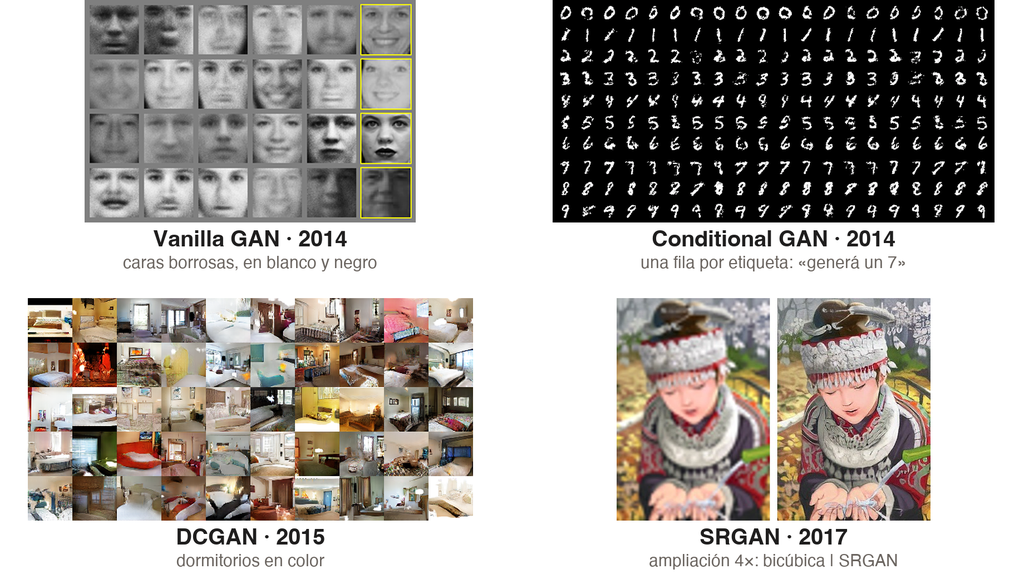

Tipos y aplicaciones

## El salto que lo cambió todo: StyleGAN (2018)

El problema que nadie había resuelto en cuatro años: las GANs generaban imágenes, pero no podías pedirle "genera una cara joven, con pelo castaño y expresión neutral". El Generador mezclaba todos los atributos juntos sin control.

ComponenteQué haceQué controla

Red de mapeo (mapping network)Transforma el ruido en un vector de estilo (w)Define las características globales de la imagen

Síntesis por capas (AdaIN)Inyecta el estilo en distintas capas de la redCada capa controla una escala diferente de detalle

Ruido estocástico por capaAñade variación aleatoria capa a capaControla variaciones finas: poros, pelo suelto, arrugas

**Style mixing**: StyleGAN permite tomar la estructura de una cara (pose, forma) y el estilo de otra (color de pelo, edad) para generar una cara completamente nueva con coherencia total. Esto no era posible en ninguna GAN anterior.

Tipos y aplicaciones

## StyleGAN: arquitectura

Dos redes en lugar de una: la red de mapeo convierte el ruido z en un estilo w, y la red de síntesis arma la imagen de 4×4 a 1024×1024 inyectando ese estilo en cada bloque.

[figure not shown]

Tipos y aplicaciones

## StyleGAN: Innovaciones Clave (Resumen)

StyleGAN (NVIDIA) redefine la generación de imágenes al modificar únicamente el Generador, manteniendo el Discriminador estándar. Sus tres innovaciones arquitectónicas permiten control fino sobre el estilo y alta calidad visual.

### Progressive Growing

Entrena comenzando con imágenes de 4×4 píxeles y agrega capas progresivamente hasta 1024×1024. Mejora la estabilidad del entrenamiento y la calidad final.

### Bi-linear Sampling

Reemplaza el muestreo nearest-neighbor por bi-linear sampling en up/downsampling, reduciendo artefactos y logrando transiciones más suaves.

### Mapping Network + AdaIN

Una red de 8 capas transforma el vector latente z en un vector intermedio w, que modula las características vía AdaIN. Permite controlar textura, iluminación y estilo de forma independiente por nivel.

Fuente: GeeksforGeeks — StyleGAN: Style Generative Adversarial Networks

Tipos y aplicaciones

## ThisPersonDoesNotExist.com en números

Cada vez que se recarga thispersondoesnotexist.com (Phillip Wang, febrero de 2019), StyleGAN de NVIDIA genera una cara nueva a partir de un vector de 512 números. Lo que hay detrás:

70.000fotos de caras reales de Flickr (dataset FFHQ), de 1024 × 1024 píxeles

26,2 millonesde parámetros en el Generador de StyleGAN

25 millonesde imágenes vistas por el Discriminador durante el entrenamiento: cada foto pasa cientos de veces

≈ USD 1.000para entrenarla hoy: una semana en 8 GPUs V100 alquiladas (entre USD 200 y 3.900 según dónde)

**En Slanted Land el Discriminador tenía 5 números: 4 pesos y un sesgo.**

Tipos y aplicaciones

## Fortaleza 1: Generación de imágenes realistas

El resultado más sorprendente de las GANs: imágenes que el ojo humano no puede distinguir de las reales. Después de millones de rondas de entrenamiento, el Generador aprendió la estructura profunda de cómo lucen esas imágenes — proporciones, distribución de luz, imperfecciones que hacen que algo parezca real.

### ThisPersonDoesNotExist.com

Cada recarga genera un rostro humano completamente inventado con StyleGAN. Ninguno existe en el mundo real.

### Test de Turing visual (Salimans et al., 2016)

Jueces humanos no distinguen las muestras de MNIST de los dígitos reales. Con CIFAR-10 se equivocan en el 21,3 % de los casos.

### Videojuegos y entretenimiento

Las GANs generan texturas, escenarios y personajes con un nivel de detalle que antes requería artistas trabajando manualmente durante días.

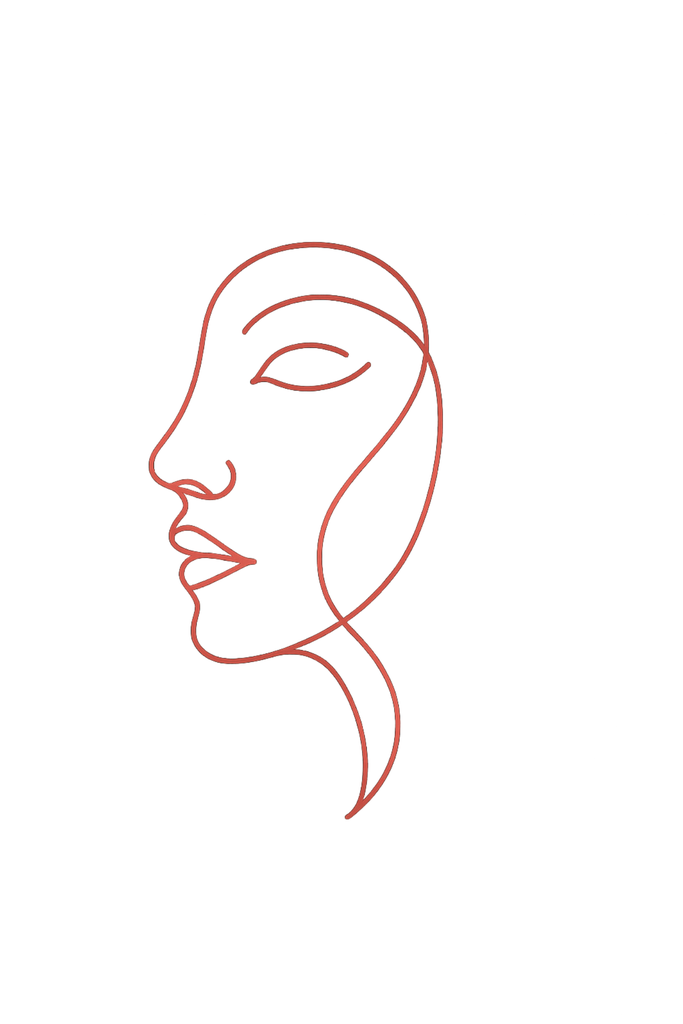

Tipos y aplicaciones

## Fortaleza 2: Transformación de imágenes (Image Translation)

Las GANs pueden transformar una imagen en otra y conservar la estructura subyacente.

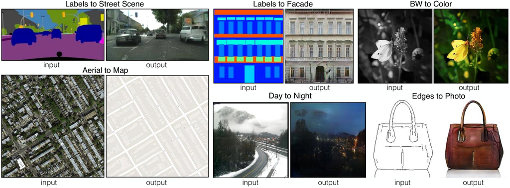

#### Pix2Pix: aprende de pares de imágenes alineadas

El mismo modelo, entrenado con distintos datos: de etiquetas a una calle, de foto aérea a mapa, de día a noche, de boceto a foto, de blanco y negro a color.

[figure not shown]

#### CycleGAN: aprende sin pares, y para muchas tareas no hay pares disponibles

De caballo a cebra y de cebra a caballo, de foto a pintura de Monet, de verano a invierno, a partir de dos colecciones de imágenes sueltas.

Tipos y aplicaciones

## Image Translation: modelos y librerías

En medicina, la misma técnica convierte MRI en CT sin escanear dos veces al paciente, lo que reduce costes, tiempo y exposición a radiación.

InputOutputModeloLibrería o referencia

Boceto de un edificioFoto del edificio terminadoPix2Pixpytorch-CycleGAN-and-pix2pix

Foto de díaLa misma foto de nochePix2Pixpytorch-CycleGAN-and-pix2pix

Imagen de un caballoLa misma imagen con una cebraCycleGANpytorch-CycleGAN-and-pix2pix

Imagen de baja resoluciónAlta resolución (super-resolución)SRGANReal-ESRGAN, sucesor práctico de SRGAN

Imagen en blanco y negroLa misma imagen en colorDeOldify / CycleGANDeOldify (archivado en 2024)

MRI de cerebroImagen equivalente de CTCycleGAN médico[Wolterink et al., 2017](https://arxiv.org/abs/1708.01155) (paper)

Tipos y aplicaciones

## Fortaleza 3: Completado de imágenes (Image Inpainting)

Las GANs pueden reconstruir regiones faltantes de forma coherente con el contexto. La red recibe una imagen con una región enmascarada e infiere el contenido más probable basándose en colores, texturas y estructuras adyacentes. No copia píxeles cercanos — entiende el contenido semántico de la escena completa.

- **En la imagen**: a la izquierda, la foto con zonas borradas en blanco; a la derecha, lo que completó la GAN, sin retoques (DeepFill, Yu et al., 2018).
- **Tomografías con dosis reducida**: Recupera la información sacrificada en protocolos de baja radiación, protegiendo al paciente sin perder calidad diagnóstica.

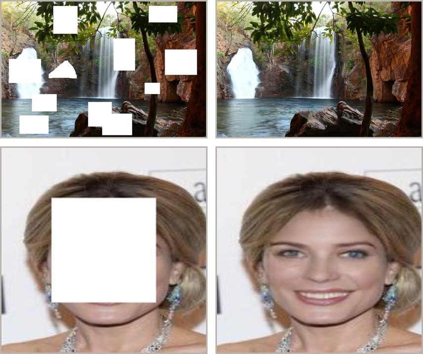

Tipos y aplicaciones

## El dataset importa: lo que le das es lo que obtenés

Una GAN solo puede generar lo que aprendió. Si el dataset mezcla clases sin etiquetas, el Generador produce híbridos incoherentes, inútiles para entrenar clasificadores. Cada clase del dataset tiene que ser homogénea, o hace falta una Conditional GAN.

Tipo de datasetLo que genera la GAN

Solo imágenes de gatosGatos variados y realistas ✓

Solo imágenes de perrosPerros variados y realistas ✓

Gatos + perros sin etiquetaHíbridos incoherentes ✗

Gatos + perros con etiqueta (cGAN)Puede generar cada clase por separado ✓

Antes de entrenar hay que validar el dataset como cualquier entrada de un pipeline de datos: limpio, bien etiquetado y homogéneo dentro de cada clase.

01IA generativa de visión 02Introducción a las GANs 03Slanted Land 04Tipos y aplicaciones 05Limitaciones y cierre

05

Limitaciones y cierre

Limitaciones y cierre

## Limitaciones (1 de 2): los problemas de entrenamiento

### Mode Collapse — el más común y frustrante

El Generador descubre un "truco": produce siempre el mismo tipo de imagen que engaña al Discriminador, en lugar de aprender toda la variedad posible.

Analogía: el falsificador que solo falsifica un tipo de billete. Con MNIST, una GAN colapsada genera siempre el mismo dígito, y ese dataset sintético no sirve para entrenar un clasificador de los diez.

### Inestabilidad en el entrenamiento

El balance entre Generador y Discriminador es frágil. Si el Discriminador es demasiado bueno, el Generador no recibe señal útil y el gradiente "desaparece". Si el Discriminador es demasiado malo, el Generador aprende trucos baratos en lugar de aprender la distribución real.

[figure not shown]

Limitaciones y cierre

## Limitaciones (2 de 2): evaluación, coste y sesgo

### Dificultad para evaluar la calidad

No existe una métrica universal. Las más usadas — FID e Inception Score (IS) — son aproximaciones imperfectas que no reemplazan la evaluación humana experta.

### Alta demanda computacional

Entrenar una GAN de calidad requiere GPUs potentes, datasets grandes y horas o días de entrenamiento. Una barrera real para equipos con recursos limitados.

### Sesgo heredado del dataset

Si los datos tienen sesgos — subrepresentación de grupos demográficos o patologías concretas — las imágenes generadas van a heredar y amplificar esos sesgos.

Limitaciones y cierre

## Cierre: lo que aprendimos y lo que sigue

**En este capítulo construimos la comprensión de las GANs desde cero, siguiendo una narrativa completa:**

1

#### La intuición

El falsificador y el detective, compitiendo para mejorar mutuamente.

2

#### La arquitectura

Generador y Discriminador como implementación técnica de esa intuición.

3

#### El entrenamiento

El ciclo de cinco pasos que hace converger al sistema, con el ejemplo de Slanted Land.

4

#### La lógica matemática

5

#### Fortalezas y limitaciones

Tres capacidades concretas (generar, traducir y completar imágenes) y los problemas a resolver antes de usar GANs en producción.

Limitaciones y cierre

## Práctica: entrenar una GAN

- **Vanilla GAN**: python train_vanilla_gan.py: entrena con MNIST, que se descarga solo.
- **Conditional GAN**: python train_cgan.py: genera el dígito que le piden, del 0 al 9.
- **DCGAN**: python train_dcgan.py: entrena con caras de CelebA.
- **Link**: github.com/gordicaleksa/pytorch-gans#training